# Assignment

2025-02-01

# Creating the data

Firstly, I am asking R to simulate a speed dating dataset. I am defining the folder path & then creating the folder, while checking before if it doesn’t already exist.

data_folder <- “plotting_assignment/data” if (!dir.exists(data_folder)) {dir.create(data_folder, recursive = TRUE)}

For reproducibility: set.seed(123)

Number of participants: n <- 1000

speed_dating_data <- data.frame(

With id from 1 to n (1000): participant_id = 1:n,

With age between 18 and 40, the same age can be chosen more than once: age = sample(18:40, n, replace = TRUE),

I am considering only cis people: gender = sample(c(“Male”, “Female”), n, replace = TRUE),

Random scores from 1 to 10, simulating attractiveness: attractiveness_rating = runif(n, 1, 10),

0 = No match, 1 = Match of interests, 60% chances of no match, 40% of match: interests_match = sample(0:1, n, replace = TRUE, prob = c(0.6, 0.4)),

Randomly assign a partner_id (random partner for each participant):

partner_id = sample(1:n, n, replace = TRUE))

Save the data as a CSV file inside the “data” folder:

write.csv(speed_dating_data, file = file.path(data_folder, “speed_dating_data.csv”), row.names = FALSE)

Message to confirm:

cat(“Speed dating dataset created and saved in ‘plotting_assignment/data/speed_dating_data.csv’”)

```r
data_folder <- "plotting_assignment/data"

if (!dir.exists(data_folder)) {dir.create(data_folder, recursive = TRUE)}

set.seed(123)

n <- 1000

speed_dating_data <- data.frame(
participant_id = 1:n,
age = sample(18:40, n, replace = TRUE),
gender = sample(c("Male", "Female"), n, replace = TRUE),
attractiveness_rating = runif(n, 1, 10),
attraction_feeling = sample(0:1,n, replace = TRUE, prob = c(0.5,0.5)),
interests_match = sample(0:1, n, replace = TRUE, prob = c(0.6, 0.4)),
partner_id = sample(1:n, n, replace = TRUE))

write.csv(speed_dating_data, file = file.path(data_folder, "speed_dating_data.csv"), row.names = FALSE)

cat("Speed dating dataset created and saved in 'plotting_assignment/data/speed_dating_data.csv'\n")
```

```
## Speed dating dataset created and saved in 'plotting_assignment/data/speed_dating_data.csv'
```

# Data wrangling

installing dplyr: library(dplyr)

Renaming: liked_data <- speed_dating_data %>%

Keeping only the ones who felt an attraction: filter(attraction_feeling == 1) %>%

Keeping only the subject’s participant id, age & the partner’s id: select(participant_id, age, partner_id) %>%

Joining by attracted id: left_join(speed_dating_data, by = c(“partner_id” = “participant_id”)) %>%

Selecting age & gender of participant & partner: select(participant_id, age.x, gender.x, partner_id, age.y, gender.y) %>%

Renaming to distinguish more easily: rename(subject = participant_id, subject_age = age.x, subject_gender = gender.x, partner = partner_id, partner_age = age.y, partner_gender = gender.y)

To view the results: head(liked_data)

```r
library(dplyr)
liked_data <- speed_dating_data %>%
filter(attraction_feeling == 1) %>%
select(participant_id, age, gender, partner_id) %>%
left_join(speed_dating_data, by = c("partner_id" = "participant_id")) %>%
select(participant_id, age.x, gender.x, partner_id, age.y, gender.y) %>%
rename(subject = participant_id, subject_age = age.x, subject_gender = gender.x, partner = partner_id, partner_age = age.y, partner_gender = gender.y)
```

# Good Plot

For visualisation: library(ggplot2) To create ridge density plots: library(ggridges)

Converting gender into a factor, to make it categorical: liked_data$subject_gender <- as.factor(liked_data$subject_gender)

Subgroupig into 3: liked_data$subject_age_group <- with(liked_data, paste0(floor((subject_age - 18) / 3) * 3 + 18, “-”, floor((subject_age - 18) / 3) * 3 + 20))

mean_data <- liked_data %>% group_by(subject_age_group, subject_gender) %>%

Calculating the mean partner_age for each group: summarise(mean_partner_age = mean(partner_age, na.rm = TRUE)) %>%

ungrouping for eventual further processing: ungroup()

Creating the plot: ggplot(liked_data, aes(x = partner_age, y = subject_age_group, fill = subject_gender)) +

To control transparency: geom_density_ridges(alpha = 0.7) +

Adding a “mean point”: geom_point(data = mean_data, aes(x = mean_partner_age, y = subject_age_group), shape = 21, size = 3, fill = “black”, color = “white”) +

Creating two separate plots for two genders:  
facet_wrap(~ subject_gender) + labs(title = “Age Preferences in Dating: Differences across Age groups and Gender”, x = “Liked Age”, y = “Subjects”, Fill = “Gender”) +

Adding for clarity a scale specification: + scale_x_continuous(breaks = seq(10, 40, by = 5))  
theme_minimal()

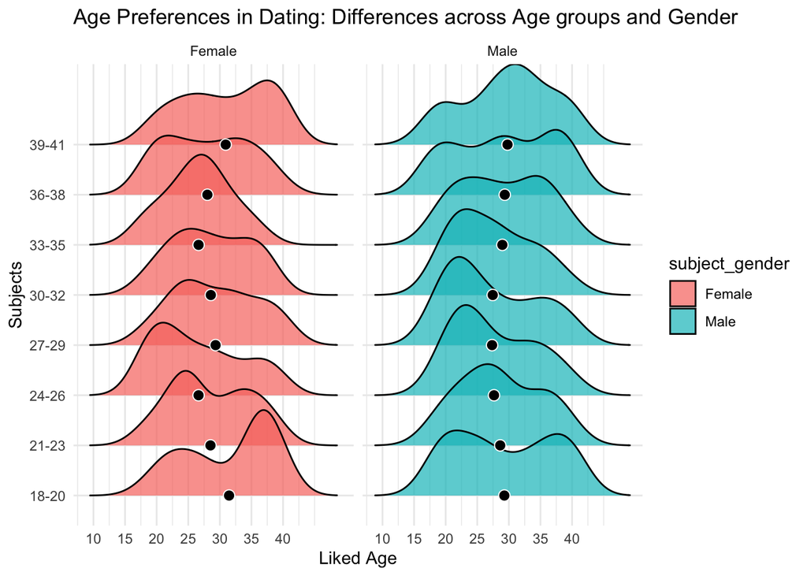

```r
liked_data$subject_gender <- as.factor(liked_data$subject_gender)

library(ggplot2)
library(ggridges)

liked_data$subject_age_group <- with(liked_data, paste0(floor((subject_age - 18) / 3) * 3 + 18, "-", floor((subject_age - 18) / 3) * 3 + 20))

mean_data <- liked_data %>%
  group_by(subject_age_group, subject_gender) %>%
  summarise(mean_partner_age = mean(partner_age, na.rm = TRUE)) %>%
  ungroup()
ggplot(liked_data, aes(x = partner_age, y = subject_age_group, fill = subject_gender)) +
  geom_density_ridges(alpha = 0.7) +
  geom_point(data = mean_data, aes(x = mean_partner_age, y = subject_age_group),
             shape = 21, size = 3, fill = "black", color = "white") +
  facet_wrap(~ subject_gender) +
  labs( title = "Age Preferences in Dating: Differences across Age groups and Gender",
    x = "Liked Age",
    y = "Subjects",
    Fill = "Gender") +
  scale_x_continuous(breaks = seq(10, 40, by = 5)) +
  theme_minimal()
```

# Description

This plot illustrates age preferences in dating, grouped by age ranges and separated by gender. The x-axis represents the age of the preferred partner (“Liked Age”), while the y-axis categorizes the age groups of the participants (“Subjects”). Each gender is represented in a separate facet for comparison.

The density curves show the distribution of preferred ages within each age group, highlighting the most frequently preferred ages. The black dots represent the mean preferred age for each group, providing a summary of the central tendency.

Key observations:

Both genders show similar trends, with a preference concentrated around the age of 30. The shape of the distributions indicates slight variations in preferences across age groups, though the overall pattern remains consistent. The lack of significant divergence between genders suggests similar preferences in terms of the most desirable age range.

# Bad Plot

Creating raincloud plot: ggplot(liked_data, aes(x = subject_age, y = partner_age, fill = subject_gender )) +

Violin plot for the distribution: geom_violin(scale = “area”, alpha = 0.5, trim = TRUE) +

Boxplot for central tendency: geom_boxplot(width = 0.2, fill = “white”, color = “black”, outlier.shape = NA) +

Dot plot for individual data points: geom_dotplot(binaxis = “y”, stackdir = “center”, dotsize = 1, fill = “black”) +

Customization: theme_minimal() + labs( title = “Age Distribution of subject and partner”, x = “subject ID”, y = “Age” ) + theme( plot.title = element_text(size = 16), axis.title = element_text(size = 14), axis.text = element_text(size = 12))

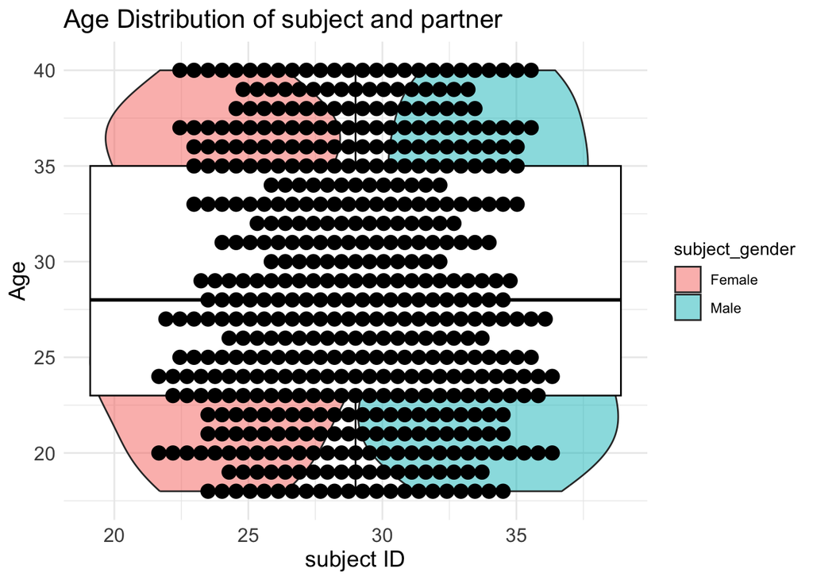

```r
ggplot(liked_data, aes(x = subject_age, y = partner_age, fill = subject_gender )) +
  geom_violin(scale = "area", alpha = 0.5, trim = TRUE) +
  geom_boxplot(width = 0.2, fill = "white", color = "black", outlier.shape = NA) +
  geom_dotplot(binaxis = "y", stackdir = "center", dotsize = 1, fill = "black") +
  theme_minimal() +
  labs(
    title = "Age Distribution of subject and partner",
    x = "subject ID",
    y = "Age") +
  theme(
    plot.title = element_text(size = 16),
    axis.title = element_text(size = 14),
    axis.text = element_text(size = 12))
```

# Description

The x-axis label is misleading: it is labeled “subject ID,” but it does not represent individual IDs, instead their age. The points are overlapping heavily, obscuring the individual data points. The violin plot misleads if there’s a sample sizes difference. The combination of violin plot, boxplot, and dot plot creates visual redundancy, making the graph busy and harder to interpret. The title, “Age Distribution of subject and partner,” is vague. It’s unclear if the graph compares subject and partner ages or shows general age distribution by gender.